# THmodel_mcmc_commented

Sophia Ng, Josh Petrie, Richard Evans

October, 05, 2017

```r
suppressPackageStartupMessages(library(tidyverse))
suppressPackageStartupMessages(library(magrittr))
```

Created by Sophia Ng on Aug 31, 2015, Modified by Josh Petrie on Nov 2, 2015

# Rationale

This script estimates model parameters from the data formatted in THmodel_premcmc_commented.R using markov chain monte carlo

## Components

Hazards of infection from both the **community** and **household** contribute to the likelihood.

### Community Component

The hazard of infection at time t from the community for each cohort member, j, is modeled as:

```
R> lin.pred = para5 * AGECAT2 + para6 * AGECAT3 + para7 * HR + para8 * vax
```

$$Z_i = \theta_5I(9\leq AGE_i \lt 18) + \theta_6I(Age_i \geq 18) + \theta_7I(HR_i=1) + \theta_8I(vax(t)_i=1)$$

```
R> C.HAZ.SUM.FN = com(t) * para4 * exp(lin.pred)
```

$$\lambda_{j,C}(t_i|Z) = com(t_i) \theta_4 e^Z$$

(In publications: $\lambda_{j,C}(t|Z) = P_c(t) \psi_C exp(Z)$)

where $com(t)$ is a time varying proxy for the baseline hazard from community informed by state surveillance, $\theta_4 (\psi_c(t))$ is a scaling parameter for the baseline community hazard $\theta_5,...,\theta_8$ are parameters for the effects of various subject characteristics.

### Household Component

The daily hazard of infection for each household contact, j, from each infected individual, i, in the household is modeled as:

```
R> lin.pred = para5 * AGECAT2 + para6 * AGECAT3 + para7 * HR + para8 * vax
```

$$Z_i = \theta_5I(9\leq AGE_i \lt 18) + \theta_6I(Age_i \geq 18) + \theta_7I(HR_i=1) + \theta_8I(vax(t)_i=1)$$

```
R> HH.HAZ.SUM.FN = SI.FN(t) * para3 * exp(lin.pred)
```

$$\lambda_{HH}(t|Z) = f(\tau|\alpha, \gamma) \theta_3 e^Z$$
where SI.FN ($f(\tau|\alpha, \gamma) \sim Weibull(\alpha, \gamma)$) is a weibull distribution that models the serial interval (time in days between symptom onset of prior and subsequent influenza cases) in those households where influenza has been introduced:

$$f(\tau|\alpha, \gamma) = e^{-(t/\theta_1)^{\theta_2}} - e^{-((t+1)/\theta_1)^{\theta_2}}$$

```
R> exp(-(t/para1)^para2) - exp(-((t+1)/para1)^para2),
```

where para1 ($\theta_1$ or $\gamma$) and para2 ($\theta_2$ or $\alpha$) are shape parameters for the weibull distribution

para3 ($\theta_3$) is a constant parameter representing the baseline household hazard of infection para5 - para8 ($\theta_5,...,\theta_8$) are parameters for the effects of various subject characteristics

### Total Hazard and Likelihood

The total hazard of infection is the **sum** of the hazards from the **household** and from the **community**.

$$\lambda_j(t|Z) = \lambda_{j,C}(t|Z) + \sum_{i=1}^n\lambda_{HH,i \rightarrow j}(\tau|Z)$$

MCMC is used to estimate $\Theta = \left\{\theta_1,...,\theta_8\right\}$

The contribution to the likelihood for those **NOT** infected during follow up, and prior to the date of illness onset for those who were infected is:

```
R> exp(-1 * pre.haz)
```

$$e^{-\lambda_{pre}}$$

*pre.haz* is the sum of the hazards of infection from the community (*pre.c.haz*) and from the household (*pre.hh.haz*) prior to infection ($\lambda_{pre} = \lambda_{j,C}(t_i|Z) + \lambda_{HH, pre}(t|Z)$).

The additional contribution to the likelihood on the date of illness onset for those infected during follow up is:

```
R> 1 - exp(-1 * on.haz)
```

$$1-e^{-\lambda_{on}}$$

*on.haz* is the sum of the hazards of infection from the community (*ondate.c.haz*) and from the household (*ondate.hh.haz*) on the date of illness onset for those infected ($\lambda_{on} = \lambda_{j,C}(t_i|Z) + \lambda_{HH, on}(t|Z)$)

The full likelihood:

The contribution of the likelihood function from each infected individual is the probability that they were infected on their day of illness onset, $t_{j0}$, multiplied by the probability that they escaped infection each day prior to their illness onset

$$p(Y_j = 1, t_j=t_{j,0}) = (1 - e^{-\lambda_j(t_{j0})})(e^{-\sum_{d=1}^{t_{j0}-1}\lambda_j(d)})$$

The contribution to the likelihood function for each individual not infected during the study period is the probability that they escaped infection each day of the influenza season.

$$p(Y_j = 0, t_j=t_{end}+1) = e^{-\sum_{d=1}^{t_j}\lambda_j(d)}$$

The overall likelihood:

$$f(Z|\Theta) = L(\Theta|Z) = \sum_{j:y_j=1}log(1-e^{-\lambda_j(t_{j0})}) - \sum_j\sum_{d=1}^{t_j}\lambda_j(d)$$

# Load Data

Must have previously run the file *THmodel_pre_mcmc_commented.R* first on study data. See *THmodel_premcmc_commended.Rmd* or *THmodel_premcmc_commended.html* for details.

```r
if(!suppressPackageStartupMessages(require(MESS)))
  install.packages("MESS")

# Read and Format the data
setwd("S:/MartinEpi/Projects/BoV-Uganda/Graphs and Reports/HH-transmission-model-master_2/premcmc_data")
ondate.c.exp <- readRDS("ondate.c.exp.rds")
ondate.hh.exp <- readRDS("ondate.hh.exp.rds")
preinf.c.exp <- readRDS("preinf.c.exp.rds")
preinf.hh.exp <- readRDS("preinf.hh.exp.rds")
```

# MCMC model program

theta: vector of parameter estimates from THmodel_mcmc_commented $\Theta = \left\{\theta_1,...,\theta_8\right\}$

they are as follows: $\alpha$ (weibull shape), $\gamma$ (weibull scale), HH baseline hazard, community hazard scale, age 9-17 (coeff), age 18+ (coeff), high risk condition (coeff), vaccination (coeff)

```
theta <- c(q, k, hh base haz, com haz scale, Age 9-17, Age 18+, HighRisk, Vaccination)
```

## Prior Function -

usually we set non-informative (flat) priors, e.g. Uniform(a,b) or Normal(mu,sigma) with relatively large sigma.

```r
logprior <- function(current) {
  # write your own prior function here (CHANGE)
  current$logprior <- dunif(current$theta1, 0, 10, log = TRUE)
    + dunif(current$theta2, 0, 10, log = TRUE)
    + dunif(current$theta3, 0, 1, log = TRUE)
    + dunif(current$theta4, 0, 1, log = TRUE)
    + dnorm(current$theta5, 0, 100, log = TRUE)
    + dnorm(current$theta6, 0, 100, log = TRUE)
    + dnorm(current$theta7, 0, 100, log = TRUE)
    + dnorm(current$theta8, 0, 100, log = TRUE)
  current
}
```

## Serial interval (SI.FN)

```r
SI.FN <- function(current, EXPDAY) {
  exp(-(EXPDAY / current$theta1) ^ current$theta2) -
    exp(-((EXPDAY + 1) / current$theta1) ^ current$theta2)
}
```

## Daily Hazard of Infection for each HH contact, j, from each infected individual, i, in HH

```r
HH.HAZ.SUM.FN <- function(INPUT, current) {
  input_df <- as.data.frame(INPUT)
  d <- input_df$expday
  lin.pred <- current$theta5 * input_df$AGECAT2 +
              current$theta6 * input_df$AGECAT3 +
              current$theta7 * input_df$HR +
              current$theta8 * input_df$vax
  response <- SI.FN(current, d) * current$theta3 * exp(lin.pred)
  sum(response, na.rm = TRUE)
}
```

## Daily hazard of infection from the community for each member, j

```r
C.HAZ.SUM.FN <- function(INPUT, current) {
  input_df <- as.data.frame(INPUT)
  com <- input_df$com
  lin.pred <- current$theta5 * input_df$AGECAT2 +
              current$theta6 * input_df$AGECAT3 +
              current$theta7 * input_df$HR +
              current$theta8 * input_df$vax
  response <- com * current$theta4 * exp(lin.pred)
  sum(response)
}
```

## The likelihood function

```r
loglike <- function(current, PRE.HH, PRE.C, ON.HH, ON.C) {
  # Apply HH.HAZ.SUM.FN to the data
  # to obtain the hazard of household infection prior to illness onset...
  pre.hh.haz <- sapply(PRE.HH, HH.HAZ.SUM.FN, current = current)

  #...and on the day of illness onset for those infected
  on.hh.haz <- sapply(ON.HH, HH.HAZ.SUM.FN, current = current)

  # Apply C.HAZ.SUM.FN to the data
  # to obtain the hazard of community infection prior to illness onset...
  pre.c.haz <- sapply(PRE.C, C.HAZ.SUM.FN, current = current)

  # ...and on the day of illness onset for those infected
  on.c.haz <- sapply(ON.C, C.HAZ.SUM.FN, current = current)

  # Sum the household and community hazards to get total daily hazards
  #======================================================================#
  # NOTE: The hazard vectors need to be the same length to be summed, so #
  # PRE.C and PRE.HH should have 1 element per j                         #
  # ON.C and ON.HH should have 1 element per i                           #
  #======================================================================#
  pre.haz <- pre.hh.haz + pre.c.haz
  on.haz <- on.hh.haz + on.c.haz

  # The contribution to the likelihood for those NOT infected during follow up, and
  # prior to the date of illness onset for those who were infected is:
  like.not <- exp(-1 * pre.haz)
  log.like.not <- log(like.not + 0.000001) # add small non-negative value

  # The additional contribution to the likelihood on the date of illness onset
  # for those infected during follow up is:
  like.inf <- 1- exp(-1 * on.haz)
  log.like.inf <- log(like.inf + 0.0000001)

  #Total log-likelihood
  current$loglike <- sum(log.like.inf, log.like.not, na.rm = TRUE)
  current
}
```

## Function to constrain weibull shape parameters

To assure model convergence, we use goodqk to constrain the Weibull shape parameters such that the corresponding serial interval function would result in >= 80% of household secondary infections occurring within 14 days of the onset of illness in the index case

```r
goodqk <- function(current) {
  temp <- data.frame(t = 0:30, pmass = NA)
  temp$pmass <- SI.FN(current, temp$t)
  select <- temp[temp$pmass >= 0, ]
  allA <- auc(select$t, select$pmass)
  b14 <- auc(select$t[select$t < 14], select$pmass[select$t < 14])
  (b14 / allA) >= 0.8 | temp$pmass[temp$t == 0] >= 0
}

# set parameter constrains (when applicable)
bad_config <- function(current) {
  ok_config = TRUE
  # can change parameters to suit constraints, para1 should always be non-negative
  if (current$theta1 < 0  |
      current$theta2 < 0  |
      current$theta3 < 0  |
      current$theta4 <= 0 |
      current$theta3 >= 1 |
      goodqk(current) != TRUE) ok_config = FALSE

  if (is.na(current$loglike)) ok_config = FALSE

  bad = FALSE
  if (!ok_config) bad = TRUE
  bad
}
```

## Metropolis-hasting Algorithm

```r
metropolis <- function(OLD, current, PRE.HH, PRE.C, ON.HH, ON.C) {
  reject = bad_config(current)
  if (!reject) {
    current <- logprior(current)
    current <- loglike(current, PRE.HH, PRE.C, ON.HH, ON.C)
    lu <- log(runif(1))
    condition <- is.na(current$logprior +
                       sum(current$loglike) -
                       OLD$logprior -
                       sum(OLD$loglike))
    lu_chk <- current$logprior +
              sum(current$loglike) -
              OLD$logprior -
              sum(OLD$loglike)
    if (condition) reject = TRUE
    if (!condition) {
      if (lu > lu_chk) reject = TRUE
    }
  }
  if (reject) current = OLD
  current
}
```

## Monte Carlo Chain generator

Set intitial values for $\Theta \cup log(p(\Theta)) \cup log(p(y|\Theta)) = \left\{\theta_1,...,\theta_8, log(p(\Theta)), log(p(y|Theta))\right\}$ and $\sigma$ for updating parameters. $sigma$ can and should be adjusted until satisfied with the acceptance rate.

```r
inits <- list(theta1 = 2,
              theta2 = 2,
              theta3 = 0.2,
              theta4 = 0.005,
              theta5 = 0.05,
              theta6 = 0.05,
              theta7 = 0.05,
              theta8 = -0.5,
              logprior = 0,
              loglike = 0)

sigma <- list(theta1 = 1,
              theta2 = 5,
              theta3 = 0.2,
              theta4 = 0.001,
              theta5 = 0.75,
              theta6 = 0.5,
              theta7 = 0.75,
              theta8 = 0.5)
```

```r
#main function for MCMC process
mcmc <- function(PRE.HH, PRE.C, ON.HH, ON.C,
                 MCMC_iterations,
                 BURNIN_iterations,
                 THINNING = 1,
                 inits,
                 sigma) {
  # initial parameter values
  current <- inits
  # list to save posterior samples for each parameter
  dump.names <- names(sigma)
  dump <- vector("list", length(dump.names))
  names(dump) <- dump.names
  # calculate acceptance rate (45% - 55% is acceptable)
  dump$accept <- matrix(NA, ncol = 8, nrow = MCMC_iterations)
  sigma <- sigma
  # logprior for initial values
  current <- logprior(current)
  # loglike for initial values
  current <- loglike(current, PRE.HH, PRE.C, ON.HH, ON.C)

  #write posteriors at each iteration
  pb <- txtProgressBar(min = 0, max = MCMC_iterations, style = 3)
  for (iteration in (-BURNIN_iterations + 1):MCMC_iterations) {
    old <- current
    current$theta1 <- rnorm(1, current$theta1, sigma$theta1)
    current <- metropolis(old, current, PRE.HH, PRE.C, ON.HH, ON.C)
    old <- current
    current$theta2 <- rnorm(1, current$theta2, sigma$theta2)
    current <- metropolis(old,current, PRE.HH, PRE.C, ON.HH, ON.C)
    old <- current
    current$theta3 <- rnorm(1,current$theta3, sigma$theta3)
    current <- metropolis(old, current, PRE.HH, PRE.C, ON.HH, ON.C)
    old <- current
    current$theta4 <- rnorm(1,current$theta4, sigma$theta4)
    current <- metropolis(old, current, PRE.HH, PRE.C, ON.HH, ON.C)
    old <- current
    current$theta5 <- rnorm(1, current$theta5, sigma$theta5)
    current <- metropolis(old, current, PRE.HH, PRE.C, ON.HH, ON.C)
    old <- current
    current$theta6 <- rnorm(1, current$theta6, sigma$theta6)
    current <- metropolis(old, current, PRE.HH, PRE.C, ON.HH, ON.C)
    old <- current
    current$theta7 <- rnorm(1, current$theta7, sigma$theta7)
    current <- metropolis(old, current, PRE.HH, PRE.C, ON.HH, ON.C)
    old <- current
    current$theta8 <- rnorm(1, current$theta8, sigma$theta8)
    current <- metropolis(old, current, PRE.HH, PRE.C, ON.HH, ON.C)

    # save the posteriors after discarding burn-in values
    if(iteration > 0) {
      rr <- iteration
      dump$theta1[rr] <- current$theta1
      dump$theta2[rr] <- current$theta2
      dump$theta3[rr] <- current$theta3
      dump$theta4[rr] <- current$theta4
      dump$theta5[rr] <- current$theta5
      dump$theta6[rr] <- current$theta6
      dump$theta7[rr] <- current$theta7
      dump$theta8[rr] <- current$theta8

      # save the result for accept/reject at each step to help find appropriate sigma
      if(rr > 1) {
        dump$accept[rr, 1] <- 1 * (dump$theta1[rr] != dump$theta1[rr - 1])
        dump$accept[rr, 2] <- 1 * (dump$theta2[rr] != dump$theta2[rr - 1])
        dump$accept[rr, 3] <- 1 * (dump$theta3[rr] != dump$theta3[rr - 1])
        dump$accept[rr, 4] <- 1 * (dump$theta4[rr] != dump$theta4[rr - 1])
        dump$accept[rr, 5] <- 1 * (dump$theta5[rr] != dump$theta5[rr - 1])
        dump$accept[rr, 6] <- 1 * (dump$theta6[rr] != dump$theta6[rr - 1])
        dump$accept[rr, 7] <- 1 * (dump$theta7[rr] != dump$theta7[rr - 1])
        dump$accept[rr, 8] <- 1 * (dump$theta8[rr] != dump$theta8[rr - 1])
      }
    }
  setTxtProgressBar(pb, iteration)
  }
  dump
}
```

Run Sampler and inspect chains

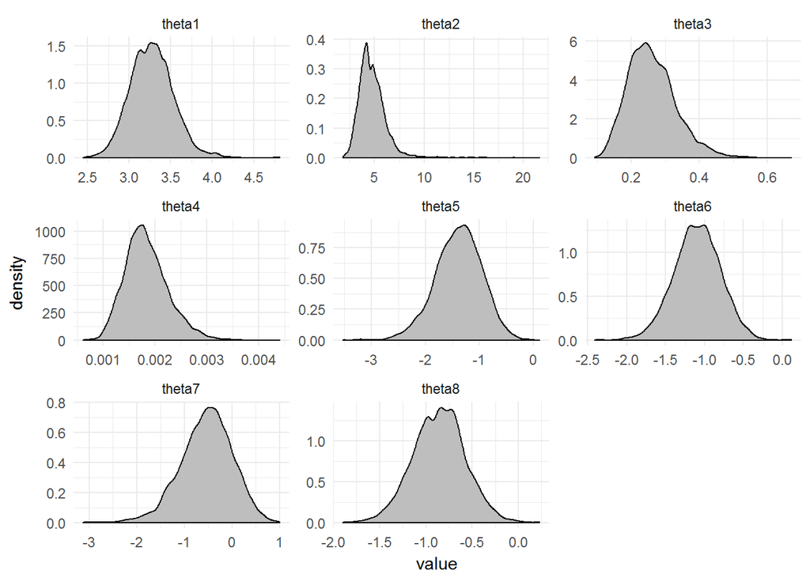

```r
# start with small number of iterations (about 1000) to tune sigmas, then do full number
# iter <- 15000
# burnin <- iter / 3

# system.time(
#   model1 <- mcmc(preinf.hh.exp, preinf.c.exp, ondate.hh.exp, ondate.c.exp,
#                  MCMC_iterations = iter,
#                  BURNIN_iterations = burnin,
#                  THINNING = 1,
#                  inits = inits,
#                  sigma = sigma)
# )
# ser         system    elapsed
# 31795.51     2.03     31810.10
#
setwd("S:/MartinEpi/Projects/BoV-Uganda/Graphs and Reports/HH-transmission-model-master_2/mcmc_output")
# saveRDS(model1, file = "model1.rds")
model1 <- readRDS("model1.rds")

chains <- do.call(cbind, model1[1:8]) %>%
  as.data.frame() %>%
  reshape2::melt()

chains %>%
  ggplot(aes(value)) %>%
  add(geom_density(fill = "grey")) %>%
  add(facet_wrap(~variable, scales = "free")) %>%
  add(theme_minimal())
```

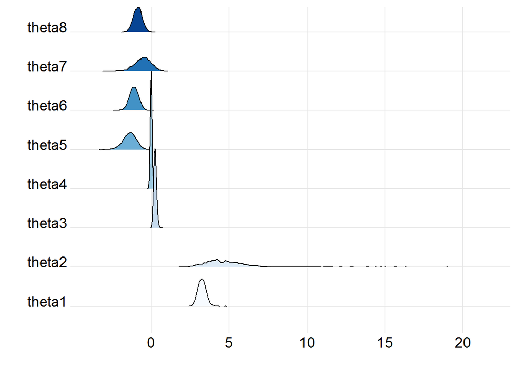

```r
library(ggridges)
chains %>%
  ggplot(aes(x = value, y = variable)) %>%
  add(geom_density_ridges(aes(fill = variable),
    rel_min_height = 0.0001,
    scale = 3)) %>%
  add(theme_ridges()) %>%
  add(theme(legend.position = "none")) %>%
  add(scale_fill_brewer()) %>%
  add(labs(x = "", y = ""))
```